# Case study 3: Triangulating causal estimates with literature evidence

This RMarkdown document demonstrates how key elements from the [notebook for case study 3 in the EpiGraphDB paper](https://github.com/MRCIEU/epigraphdb/blob/master/paper-case-studies/case-3-literature-triangulation.ipynb) can be achieved using the R package. For detailed explanations of the case study please refer to the paper or the [case study notebook](https://github.com/MRCIEU/epigraphdb/blob/master/paper-case-studies/case-3-literature-triangulation.ipynb).

## Context

The biomedical literature contains a wealth of information than far exceeds our capacity for systematic manual extraction. For this reason, there are many existing literature mining methods to extract the key concepts and content. Here we use data from [SemMedDB](https://skr3.nlm.nih.gov/SemMedDB/), a well established database that provides subject-predicate-object triples from all PubMed titles and abstracts. Using a subset of this data we created MELODI-presto (https://melodi-presto.mrcieu.ac.uk/), a method to assign triples to any given biomedical query via a PubMed search and some basic enrichment, and have applied this systematically to traits represented in EpiGraphDB. This allows us to identify overlapping terms connecting any set of GWAS traits, e.g. exposure and disease outcome. From here we can attempt to triangulate causal estimates, and conversely, check the mechanisms identified from the literature against the causal evidence.

This case study goes as follows:

- For an exposure trait we identify its causal evidence against other outcome traits, then link the outcomes to diseases
- Then for an exposure-outcome pair we look for its literature evidence, and the mechanisms (as SemMed triples) identified from the literature evidence
- Finally we look into detail the mechanisms specifically related to an overlapping term and visualise these mechanisms.

```r
library("magrittr")
library("dplyr")
library("purrr")
library("glue")
library("ggplot2")
library("igraph")
library("epigraphdb")
```

Here we set the starting trait, which we will use to explore associated disease traits.

```r
STARTING_TRAIT <- "Sleep duration"
```

## Get traits MR association

Given an exposure trait, find all traits with causal evidence. This method searches the causal evidence data for cases where our exposure trait has a potential casual effect on an outcome trait.

```r
get_mr <- function(trait) {
  endpoint <- "/mr"
  params <- list(
    exposure_trait = trait,
    pval_threshold = 1e-10
  )
  mr_df <- query_epigraphdb(route = endpoint, params = params, mode = "table")
  mr_df
}

mr_df <- get_mr(STARTING_TRAIT)
mr_df %>% glimpse()
```

```
#> Rows: 1,178
#> Columns: 10
#> $ exposure.id    <chr> "ieu-a-1088", "ieu-a-1088", "ieu-a-1088", "ieu-a-1088",…
#> $ exposure.trait <chr> "Sleep duration", "Sleep duration", "Sleep duration", "…
#> $ outcome.id     <chr> "met-a-353", "met-a-307", "ieu-a-99", "ieu-a-59", "ieu-…
#> $ outcome.trait  <chr> "Cortisol", "Cholesterol", "Hip circumference", "Hip ci…
#> $ mr.b           <dbl> 0.059176931, -0.024282343, -0.288661815, 0.072874008, 0…
#> $ mr.se          <dbl> 1.385651e-03, 5.409778e-05, 5.928478e-03, 1.617032e-04,…
#> $ mr.pval        <dbl> 0, 0, 0, 0, 0, 0, 0, 0, 0, 0, 0, 0, 0, 0, 0, 0, 0, 0, 0…
#> $ mr.method      <chr> "FE IVW", "FE IVW", "FE IVW", "FE IVW", "FE IVW", "FE I…
#> $ mr.selection   <chr> "DF", "DF", "DF", "DF", "DF", "DF", "DF", "DF", "DF", "…
#> $ mr.moescore    <dbl> 1, 1, 1, 1, 1, 1, 1, 1, 1, 1, 1, 1, 1, 1, 1, 1, 1, 1, 1…
```

## Map outcome traits to disease

For this example, we are interested in traits mapped to a disease node. To do this we utilise the mapping from GWAS trait to Disease via EFO term.

```r
# NOTE: this block takes a bit of time, depending on the size of `mr_df` above.
#       We will not run the block here in package building,
#       but readers are encouraged to try it offline!
trait_to_disease <- function(trait) {
  endpoint <- "/ontology/gwas-efo-disease"
  params <- list(trait = trait)
  disease_df <- query_epigraphdb(route = endpoint, params = params, mode = "table")
  if (nrow(disease_df) > 0) {
    res <- disease_df %>% pull(`disease.label`)
  } else {
    res <- c()
  }
  res
}

outcome_disease_df <- mr_df %>%
  select(`outcome.trait`) %>%
  distinct() %>%
  mutate(disease = map(`outcome.trait`, trait_to_disease)) %>%
  filter(map_lgl(`disease`, function(x) !is.null(x)))
outcome_disease_df
```

## Take one example to look for literature evidence

For the multiple `exposure -> outcome` relationships as reported from the table above, here we look at the literature evidence for one pair in detail:

- Trait X: “Sleep duration” ([ieu-a-1088](https://gwas.mrcieu.ac.uk/datasets/ieu-a-1088/))
- Trait Y: “Coronary heart disease” ([ieu-a-6](https://gwas.mrcieu.ac.uk/datasets/ieu-a-6/)).

The following looks for enriched triples of information (Subject-Predicate-Object) associated with our two traits. These have been derived via PubMed searches and corresponding [SemMedDB](https://skr3.nlm.nih.gov/SemMedDB/) data.

```r
get_gwas_pair_literature <- function(gwas_id, assoc_gwas_id) {
  endpoint <- "/literature/gwas/pairwise"
  # NOTE in this example we blacklist to semmentic types
  params <- list(
    gwas_id = gwas_id,
    assoc_gwas_id = assoc_gwas_id,
    by_gwas_id = TRUE,
    pval_threshold = 1e-1,
    semmantic_types = "nusq",
    semmantic_types = "dsyn",
    blacklist = TRUE,
    limit = 1000
  )
  lit_df <- query_epigraphdb(route = endpoint, params = params, mode = "table")
  lit_df
}

GWAS_ID_X <- "ieu-a-1088"
GWAS_ID_Y <- "ieu-a-6"
lit_df <- get_gwas_pair_literature(GWAS_ID_X, GWAS_ID_Y)

glimpse(lit_df)
```

```
#> Rows: 1,000
#> Columns: 20
#> $ gwas.id          <chr> "ieu-a-1088", "ieu-a-1088", "ieu-a-1088", "ieu-a-1088…
#> $ gwas.trait       <chr> "Sleep duration", "Sleep duration", "Sleep duration",…
#> $ gs1.pval         <dbl> 9.468989e-05, 2.478516e-06, 2.478516e-06, 1.854114e-0…
#> $ gs1.localCount   <int> 2, 2, 2, 2, 2, 2, 2, 2, 2, 2, 2, 2, 2, 2, 2, 2, 2, 2,…
#> $ st1.name         <chr> "Sulpiride", "Glycine", "Glycine", "gamma-aminobutyri…
#> $ s1.id            <chr> "C0038803:INTERACTS_WITH:C0003596", "C0017890:STIMULA…
#> $ s1.subject_id    <chr> "C0038803", "C0017890", "C0017890", "C0016904", "C001…
#> $ s1.object_id     <chr> "C0003596", "C0033487", "C0033487", "C0033487", "C003…
#> $ s1.predicate     <chr> "INTERACTS_WITH", "STIMULATES", "STIMULATES", "STIMUL…
#> $ st.name          <chr> "Apomorphine", "propofol", "propofol", "propofol", "p…
#> $ st.type          <list> <"orch", "phsu">, <"orch", "phsu">, <"orch", "phsu">…
#> $ s2.id            <chr> "C0003596:TREATS:C0242350", "C0033487:AUGMENTS:C01517…
#> $ s2.subject_id    <chr> "C0003596", "C0033487", "C0033487", "C0033487", "C003…
#> $ s2.object_id     <chr> "C0242350", "C0151744", "C0010054", "C0151744", "C001…
#> $ s2.predicate     <chr> "TREATS", "AUGMENTS", "TREATS", "AUGMENTS", "TREATS",…
#> $ gs2.pval         <dbl> 0.045878175, 0.002682225, 0.001627351, 0.002682225, 0…
#> $ gs2.localCount   <int> 3, 2, 2, 2, 2, 2, 3, 2, 2, 2, 2, 2, 2, 2, 2, 2, 2, 2,…
#> $ st2.name         <chr> "Erectile dysfunction", "Myocardial Ischemia", "Coron…
#> $ assoc_gwas.id    <chr> "ieu-a-6", "ieu-a-6", "ieu-a-6", "ieu-a-6", "ieu-a-6"…
#> $ assoc_gwas.trait <chr> "Coronary heart disease", "Coronary heart disease", "…
```

```r
# Predicate counts for SemMed triples for trait X
lit_df %>%
  count(`s1.predicate`) %>%
  arrange(desc(n))
```

```
#> # A tibble: 7 x 2
#>   s1.predicate           n
#>   <chr>              <int>
#> 1 INTERACTS_WITH       719
#> 2 STIMULATES            96
#> 3 INHIBITS              93
#> 4 NEG_INTERACTS_WITH    51
#> 5 higher_than           23
#> 6 COEXISTS_WITH         15
#> 7 NEG_INHIBITS           3
```

```r
# Predicate counts for SemMed triples for trait Y
lit_df %>%
  count(`s2.predicate`) %>%
  arrange(desc(n))
```

```
#> # A tibble: 16 x 2
#>    s2.predicate            n
#>    <chr>               <int>
#>  1 TREATS                191
#>  2 STIMULATES            132
#>  3 CAUSES                120
#>  4 PREVENTS              117
#>  5 ASSOCIATED_WITH       103
#>  6 PREDISPOSES            83
#>  7 AFFECTS                71
#>  8 INTERACTS_WITH         62
#>  9 INHIBITS               47
#> 10 COEXISTS_WITH          34
#> 11 DISRUPTS               19
#> 12 NEG_PREVENTS           13
#> 13 higher_than             4
#> 14 AUGMENTS                2
#> 15 NEG_ASSOCIATED_WITH     1
#> 16 same_as                 1
```

### Filter the data by predicates

Sometimes it is preferable to filter the SemMedDB data, e.g. to remove less informative Predicates, such as COEXISTS_WITH and ASSOCIATED_WITH.

```r
# Filter out some predicates that are not informative
pred_filter <- c("COEXISTS_WITH", "ASSOCIATED_WITH")
lit_df_filter <- lit_df %>%
  filter(
    !`s1.predicate` %in% pred_filter,
    !`s2.predicate` %in% pred_filter
  )
lit_df_filter %>%
  count(`s1.predicate`) %>%
  arrange(desc(n))
```

```
#> # A tibble: 5 x 2
#>   s1.predicate           n
#>   <chr>              <int>
#> 1 INTERACTS_WITH       649
#> 2 INHIBITS              87
#> 3 STIMULATES            66
#> 4 NEG_INTERACTS_WITH    26
#> 5 higher_than           22
```

```r
lit_df_filter %>%
  count(`s2.predicate`) %>%
  arrange(desc(n))
```

```
#> # A tibble: 14 x 2
#>    s2.predicate            n
#>    <chr>               <int>
#>  1 TREATS                180
#>  2 STIMULATES            132
#>  3 CAUSES                120
#>  4 PREVENTS              117
#>  5 PREDISPOSES            83
#>  6 AFFECTS                70
#>  7 INTERACTS_WITH         62
#>  8 INHIBITS               46
#>  9 DISRUPTS               19
#> 10 NEG_PREVENTS           13
#> 11 higher_than             4
#> 12 AUGMENTS                2
#> 13 NEG_ASSOCIATED_WITH     1
#> 14 same_as                 1
```

## Literature results

If we explore the full table in `lit_df_filter`, we can see lots of links between the two traits, pinned on specific overlapping terms.

We can summarise the [SemMedDB semantic type](https://metamap.nlm.nih.gov/SemanticTypesAndGroups.shtml) and number of overlapping terms:

```r
lit_counts <- lit_df_filter %>%
  count(`st.type`, `st.name`) %>%
  arrange(`st.type`, desc(`n`))
lit_counts %>% print(n = 30)
```

```
#> # A tibble: 33 x 3
#>    st.type   st.name                                  n
#>    <list>    <chr>                                <int>
#>  1 <chr [2]> ethanol                                571
#>  2 <chr [2]> Oral anticoagulants                     24
#>  3 <chr [2]> Metoprolol                              20
#>  4 <chr [2]> morphine                                 7
#>  5 <chr [2]> Benzodiazepines                          4
#>  6 <chr [2]> propofol                                 4
#>  7 <chr [2]> Diazepam                                 2
#>  8 <chr [2]> Midazolam                                2
#>  9 <chr [2]> Thiopental                               2
#> 10 <chr [2]> Apomorphine                              1
#> 11 <chr [2]> Luteolin                                 1
#> 12 <chr [2]> Neostigmine                              1
```

[output cut: 19 more lines]

Note, the SemMedDB semantic types have been pre-filtered to only include a subset of possibilities.

### Plotting the overlapping term frequencies

We can also visualise the above table as a bar chart. In this case we will remove Ethanol as it is an outlier.

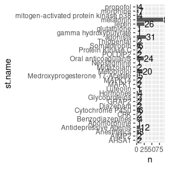

```r
lit_counts %>%
  filter(n < 100) %>%
  {
    ggplot(.) +
      aes(x = `st.name`, y = `n`) +
      geom_col() +
      geom_text(
        aes(label = `n`),
        position = position_dodge(0.9),
        hjust = 0
      ) +
      coord_flip()
  }
```

### Look in detail at one overlapping term

Here we look at cases where `leptin` is the central overlapping term.

```r
focus_term <- "leptin"
lit_detail <- lit_df_filter %>% filter(`st.name` == focus_term)
lit_detail %>% head()
```

```
#> # A tibble: 6 x 20
#>   gwas.id  gwas.trait   gs1.pval gs1.localCount st1.name s1.id     s1.subject_id
#>   <chr>    <chr>           <dbl>          <int> <chr>    <chr>     <chr>
#> 1 ieu-a-1… Sleep dura…   2.48e-6              2 Cortico… C0010124… C0010124
#> 2 ieu-a-1… Sleep dura…   2.48e-6              2 Cortico… C0010124… C0010124
#> 3 ieu-a-1… Sleep dura…   2.48e-6              2 Cortico… C0010124… C0010124
#> 4 ieu-a-1… Sleep dura…   2.48e-6              2 Cortico… C0010124… C0010124
#> 5 ieu-a-1… Sleep dura…   2.48e-6              2 Cortico… C0010124… C0010124
#> 6 ieu-a-1… Sleep dura…   2.48e-6              2 Cortico… C0010124… C0010124
#> # … with 13 more variables: s1.object_id <chr>, s1.predicate <chr>,
#> #   st.name <chr>, st.type <list>, s2.id <chr>, s2.subject_id <chr>,
#> #   s2.object_id <chr>, s2.predicate <chr>, gs2.pval <dbl>,
#> #   gs2.localCount <int>, st2.name <chr>, assoc_gwas.id <chr>,
#> #   assoc_gwas.trait <chr>
```

We can create a network diagram to visualise these relationships.

```r
lit_detail <- lit_detail %>%
  mutate_at(vars(`gwas.trait`, `assoc_gwas.trait`), stringr::str_to_upper)

# add node types: 1 - selected GWAS, 2 - traits from literature, 3 - current focus term connecting 1 and 2
nodes <- bind_rows(
  lit_detail %>% select(node = `gwas.trait`) %>% distinct() %>% mutate(node_type = 1),
  lit_detail %>% select(node = `assoc_gwas.trait`) %>% distinct() %>% mutate(node_type = 1),
  lit_detail %>% select(node = `st1.name`) %>% distinct() %>% mutate(node_type = 2),
  lit_detail %>% select(node = `st2.name`) %>% distinct() %>% mutate(node_type = 2),
  lit_detail %>% select(node = `st.name`) %>% distinct() %>% mutate(node_type = 3),
) %>% distinct()
nodes
```

```
#> # A tibble: 20 x 2
#>    node                        node_type
#>    <chr>                           <dbl>
#>  1 SLEEP DURATION                      1
#>  2 CORONARY HEART DISEASE              1
#>  3 Corticosterone                      2
#>  4 Sleep Apnea, Obstructive            2
#>  5 Phosphotransferases                 2
#>  6 JAK2                                2
#>  7 Janus kinase 2                      2
#>  8 Insulin                             2
#>  9 Adiponectin                         2
#> 10 Coronary heart disease              2
#> 11 Proteome                            2
#> 12 Endothelial dysfunction             2
#> 13 Cardiovascular Diseases             2
#> 14 Congestive heart failure            2
#> 15 Acute Coronary Syndrome             2
#> 16 Coronary Arteriosclerosis           2
#> 17 Stable angina                       2
#> 18 Metabolic syndrome                  2
#> 19 Acute myocardial infarction         2
#> 20 leptin                              3
```

```r
edges <- bind_rows(
  # exposure -> s1 subject
  lit_detail %>%
    select(node = `gwas.trait`, assoc_node = `st1.name`) %>%
    distinct(),
  # s2 object -> outcome
  lit_detail %>%
    select(node = `st2.name`, assoc_node = `assoc_gwas.trait`) %>%
    distinct(),
  # s1 subject - s1 predicate -> s1 object
  lit_detail %>%
    select(
      node = `st1.name`, assoc_node = `st.name`,
      label = `s1.predicate`
    ) %>%
    distinct(),
  # s2 subject - s2 predicate -> s2 object
  lit_detail %>%
    select(
      node = `st.name`, assoc_node = `st2.name`,
      label = `s2.predicate`
    ) %>%
    distinct()
) %>%
  distinct()
edges
```

```
#> # A tibble: 40 x 3
#>    node                     assoc_node             label
#>    <chr>                    <chr>                  <chr>
#>  1 SLEEP DURATION           Corticosterone         <NA>
#>  2 Sleep Apnea, Obstructive CORONARY HEART DISEASE <NA>
#>  3 Phosphotransferases      CORONARY HEART DISEASE <NA>
#>  4 JAK2                     CORONARY HEART DISEASE <NA>
#>  5 Janus kinase 2           CORONARY HEART DISEASE <NA>
#>  6 Insulin                  CORONARY HEART DISEASE <NA>
#>  7 Adiponectin              CORONARY HEART DISEASE <NA>
#>  8 Coronary heart disease   CORONARY HEART DISEASE <NA>
#>  9 Proteome                 CORONARY HEART DISEASE <NA>
#> 10 Endothelial dysfunction  CORONARY HEART DISEASE <NA>
#> # … with 30 more rows
```

```r
plot_network <- function(edges, nodes) {

  graph <- graph_from_data_frame(edges, directed = TRUE, vertices = nodes)
  graph$layout <- layout_with_kk

  # generate colors based on node type
  colors <- c("tomato", "lightblue", "gold")
  V(graph)$color <- colors[V(graph)$node_type]

  # Configure canvas
  default_mar <- par("mar")
  new_mar <- c(0, 0, 0, 0)
  par(mar = new_mar)

  plot.igraph(
    graph,
    vertex.size = 13,
    vertex.label.color = "black",
    vertex.label.family = "Helvetica",
    vertex.label.cex = 0.8,
    edge.arrow.size = 0.4,
    edge.label.color = "black",
    edge.label.family = "Helvetica",
    edge.label.cex = 0.5
  )
  par(mar = default_mar)
}
```

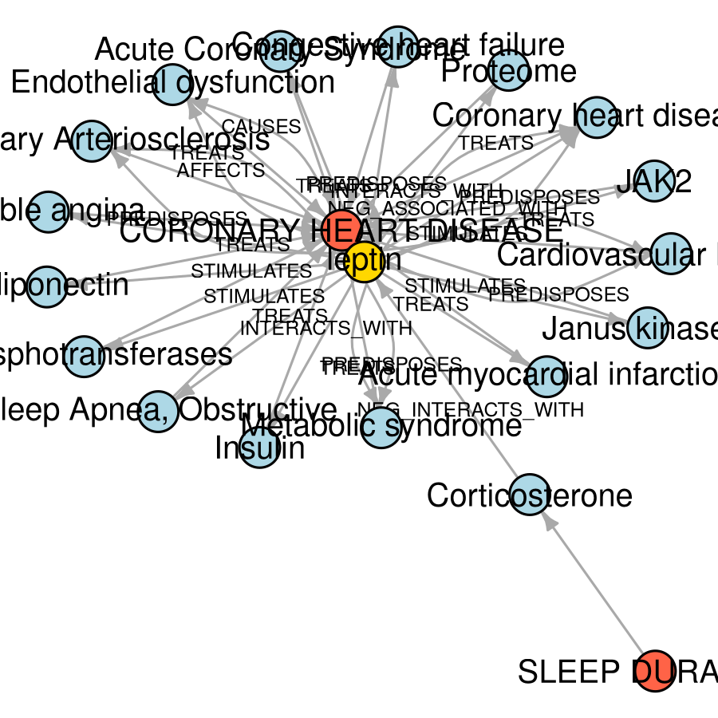

```r
plot_network(edges, nodes)
```

## Checking the source literature

We can refer back to the articles to check the text that was used to derive the SemMedDB data. This is important due to the imperfect nature of the SemRep annotation process (https://semrep.nlm.nih.gov/).

```r
get_literature <- function(gwas_id, semmed_triple_id) {
  endpoint <- "/literature/gwas"
  params <- list(
    gwas_id = gwas_id,
    semmed_triple_id = semmed_triple_id,
    by_gwas_id = TRUE,
    pval_threshold = 1e-1
  )
  df <- query_epigraphdb(route = endpoint, params = params, mode = "table")
  df %>% select(`triple.id`, `triple.name`, `lit.id`)
}

pub_df <- bind_rows(
  lit_detail %>%
    select(gwas_id = `gwas.id`, semmed_triple_id = `s1.id`) %>%
    distinct(),
  lit_detail %>%
    select(gwas_id = `assoc_gwas.id`, semmed_triple_id = `s2.id`) %>%
    distinct()
) %>%
  transpose() %>%
  map_df(function(x) get_literature(x$gwas_id, x$semmed_triple_id))
pub_df
```

```
#> # A tibble: 124 x 3
#>    triple.id                       triple.name                           lit.id
#>    <chr>                           <chr>                                 <chr>
#>  1 C0010124:NEG_INTERACTS_WITH:C0… Corticosterone NEG_INTERACTS_WITH Le… 200515…
#>  2 C0010124:NEG_INTERACTS_WITH:C0… Corticosterone NEG_INTERACTS_WITH Le… 154755…
#>  3 C0299583:TREATS:C0520679        Leptin|LEP TREATS Sleep Apnea, Obstr… 104496…
#>  4 C0299583:TREATS:C0520679        Leptin|LEP TREATS Sleep Apnea, Obstr… 104496…
#>  5 C0299583:STIMULATES:C0031727    Leptin STIMULATES Phosphotransferases 159272…
#>  6 C0299583:STIMULATES:3717        Leptin|LEP STIMULATES Janus kinase 2… 159272…
#>  7 C0299583:STIMULATES:C0169661    Leptin|LEP STIMULATES Janus kinase 2… 159272…
#>  8 C0299583:INTERACTS_WITH:C00216… Leptin INTERACTS_WITH Insulin         156480…
#>  9 C0299583:INTERACTS_WITH:C00216… Leptin INTERACTS_WITH Insulin         127240…
#> 10 C0299583:STIMULATES:C0389071    Leptin STIMULATES Adiponectin         158112…
#> # … with 114 more rows
```